# Who Survived the Titanic — and Why?

Class, Gender, Age, Family & Nationality: A Statistical Investigation

MD Noornabi | Mayerfeld Data Analytics Certificate

March 2026

## Background

On April 14–15, 1912, the RMS Titanic sank in the North Atlantic with the loss of 809 of its 1,309 recorded passengers. This analysis uses passenger-level data to answer a deceptively simple question: **who survived — and why?**

Five factors are investigated systematically: gender, passenger class, age, family size, and nationality. Each tells part of the story. Together, they reveal that survival on the Titanic was not random — it was almost entirely determined by social structure.

## Setup

```r
library(tidyverse)
library(ggplot2)
library(gridExtra)
library(scales)

mytheme <- theme_minimal(base_size=13) +
  theme(plot.title=element_text(face="bold",size=14,color="#1F4E79"),
        plot.subtitle=element_text(color="grey40",size=11),
        plot.caption=element_text(color="grey55",size=9,face="italic"),
        panel.grid.minor=element_blank(), legend.position="bottom")

surv_colors  <- c("Survived"="#27AE60","Died"="#E74C3C")
class_colors <- c("1st Class"="#1A5276","2nd Class"="#2980B9","3rd Class"="#85C1E9")
gender_colors<- c("Male"="#2980B9","Female"="#E74C3C")
```

```r
titanic <- read.csv("data/Titanic.csv", stringsAsFactors=FALSE, na.strings=c("","NA"," ")) %>%
  mutate(
    survived    = factor(survived, levels=c(0,1), labels=c("Died","Survived")),
    pclass      = factor(pclass,   levels=c(1,2,3), labels=c("1st Class","2nd Class","3rd Class")),
    Gender      = factor(Gender,   levels=c(0,1),   labels=c("Male","Female")),
    Residence   = factor(Residence,levels=c(0,1,2), labels=c("American","British","Other")),
    age         = as.numeric(age),
    fare        = as.numeric(fare),
    family_size = as.integer(sibsp) + as.integer(parch),
    survived_num= as.integer(survived=="Survived")
  )
cat("n =", nrow(titanic), "| Survived:", sum(titanic$survived=="Survived"),
    "(", round(mean(titanic$survived_num)*100,1), "%)")
```

```
## n = 1309 | Survived: 500 ( 38.2 %)
```

## 1. Exploratory Data Analysis & Missing Data Audit

```r
data.frame(
  Variable = names(titanic),
  Missing  = sapply(titanic, function(x) sum(is.na(x))),
  Pct      = round(sapply(titanic, function(x) sum(is.na(x)))/nrow(titanic)*100,1)
) %>% filter(Missing > 0) %>% arrange(desc(Pct))
```

|  | Variable | Missing | Pct |
| --- | --- | --- | --- |
| body | body | 1188 | 90.8 |
| cabin | cabin | 1014 | 77.5 |
| boat | boat | 823 | 62.9 |
| home.dest | home.dest | 564 | 43.1 |
| age | age | 263 | 20.1 |
| embarked | embarked | 2 | 0.2 |
| fare | fare | 1 | 0.1 |

> **Critical note on missing age data (20.1%):** The missingness is not random. Of the 263 missing age values, 190 belong to passengers who died vs 73 who survived. This likely reflects lower-class passengers — who were disproportionately less documented — being disproportionately represented in the deaths. Age findings must be interpreted with this bias in mind.

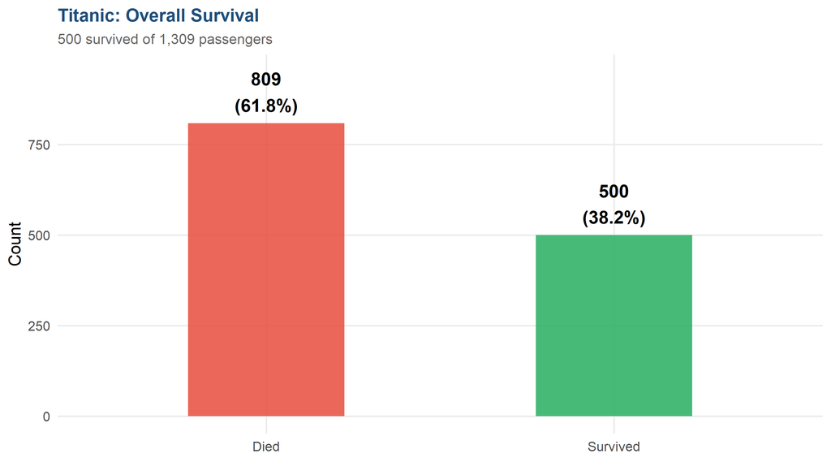

Figure 1: Overall, 38.2% of passengers survived — but this average masks enormous variation by class, gender and other factors.

```r
titanic %>% count(survived) %>%
  mutate(pct=n/sum(n)*100) %>%
  ggplot(aes(survived, n, fill=survived)) +
  geom_col(width=0.45, alpha=0.85) +
  geom_text(aes(label=paste0(n,"\n(",round(pct,1),"%)")),
            vjust=-0.3, size=5, fontface="bold") +
  scale_fill_manual(values=surv_colors) +
  scale_y_continuous(limits=c(0,950)) +
  labs(title="Titanic: Overall Survival", subtitle="500 survived of 1,309 passengers",
       x=NULL, y="Count") + mytheme + theme(legend.position="none")
```